# A reusable Bayesian IRT workflow for instrument validation

Chi Zhang & Maria Pampaka

2026-03-21

# Setup and Package/dataset Loading

```r
# Load packages
source(here::here("scripts", "00_packages.R"))
```

# Model Formulas: Three Competing Dimensional Structures

In brms, IRT models are specified as generalized linear mixed models (GLMMs). Item parameters are modelled as random intercepts grouped by item, and person parameters as random effects grouped by person id. The three structural hypotheses translate directly into different random effect specifications:

```r
# 1. Unidimensional IRT (UIRT)
# All items load on a single latent trait.
# (1 | item) = item-specific difficulty (random intercept)
# (1 | id)   = person ability (random intercept)
bf_uni <- bf(
  response ~ 1 + (1 | item) + (1 | id)
)

# 2. Correlated-Traits MIRT (CT-MIRT)
# Items load on one of three correlated dimensions.
# dim_m, dim_l, dim_p are binary indicators (0/1) assigning each item
# to its dimension.
# (0 + dim_m + dim_l + dim_p | id) estimates three person-level traits
# with an unrestricted covariance matrix, allowing correlations between
# dimensions.
bf_ct <- bf(
  response ~ 1 + (1 | item) +
    (0 + dim_m + dim_l + dim_p | id)
)

# 3. Bi-factor MIRT (BF-MIRT)
# A general factor (1 | id) plus dimension-specific factors.
# The double-bar notation (||) in brms suppresses correlations between
# random effects.
bf_bf <- bf(
  response ~ 1 + (1 | item) +
    (1 || id) +
    (0 + dim_m || id) +
    (0 + dim_l || id) +
    (0 + dim_p || id)
)
```

# Prior Specification

We use weakly informative priors throughout, following recommendations in Bürkner (2021). These provide sufficient regularisation to aid convergence without imposing strong constraints on parameter estimates.

```r
# Standard priors for person and item random effects
priors_uni <- prior("normal(0, 3)", class = "sd", group = "id") +
  prior("normal(0, 3)", class = "sd", group = "item")

# For CT models: add LKJ(2) prior on the correlation matrix between
# latent dimensions. LKJ with eta > 1 weakly favours smaller
# correlations, aiding convergence.
priors_ct <- priors_uni + prior(lkj(2), class = "cor")

# For 2PL models: add prior for log-discrimination.
priors_ct_2pl <- priors_ct +
  prior("normal(0, 1)", class = "sd", group = "item", dpar = "disc")

priors_bf_2pl <- priors_uni +
  prior("normal(0, 1)", class = "sd", group = "item", dpar = "disc")
```

# Step 1: Preprocessing sparse response categories

## Inspecting the original 5-point scale

```r
# Load the original 5-point scale data
data_1 <- readRDS(here("data", "processed", "data_1.rds"))

# Check response distribution
print(table(data_1$response))
```

```
##
##    1    2    3    4    5
##  141  913  714 1412  419
```

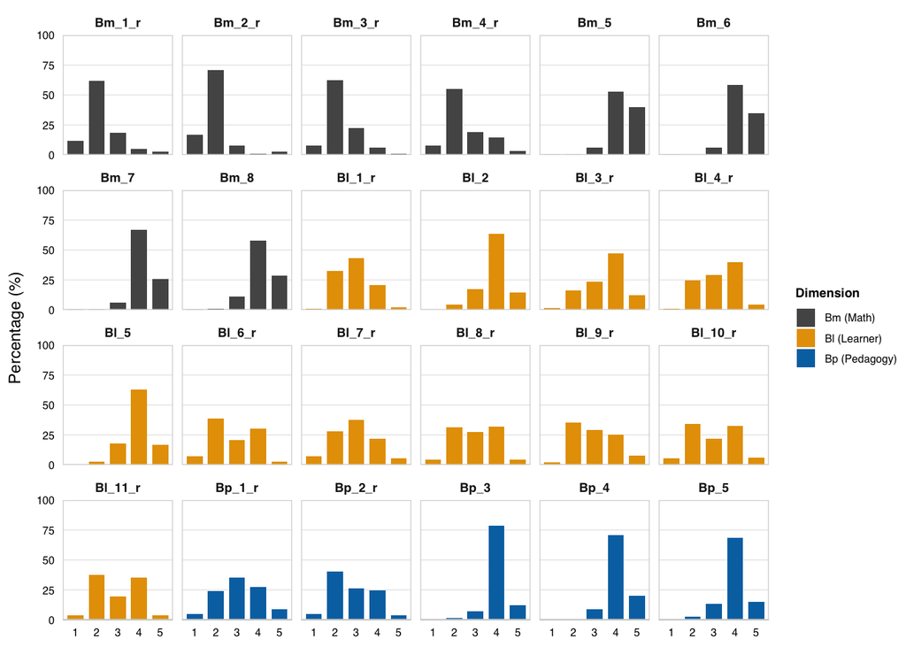

```r
# Run the plotting script to generate the descriptive plot
# This script creates the ggplot object 'fig_3'
source(here("scripts", "03_fig3.R"))

fig_3
```